# Data Science in Practice

Day 3: Data Management

Karl Ho

7/29/2020

# 1 Data Management

This session starts with basic concepts of relational database and database management systems (DBMS). Database systems constitute an integral part in dealing with large amount of data accumulated regularly in big data age. Traditional file processing systems are insufficient in dealing with increasingly sizable and complicated data composed of a variety of types and formats. Data in forms of documents, graphics, video and metadata and paradata beg for more sophisticated database systems for storage, retrieval and processing. Other requirements include consistency, security, efficiency and afforability underline the design of modern database systems.

## 1.1 What is a database?

A database is a structured collection of data about entities and their relationships. A database-management system (DBMS) is a system collecting and organizing interrelated data with set of programs to access the data. The primary goal of a DBMS is to store, retrieve and process database information in a manner that is effective, efficient and secure.

## 1.2 Database applications and database models

Databases are widely used in almost all enterprises and organizations. They provide functions such as:

- Accounting
- Banking and finance (e.g. banks)
- Sales (e.g retail, wholesale)
- Human resources
- Manufacturing
- Reservations (e.g. airlines)
- Online transactions (e.g. online stores)

Unlike data spreadsheets, database is composed of multiple tables, which could take different table structures. These tables in a database are interconnected with each other. The “relationship” of these tables are determined by the database model and design. For example, a university database is consisted of data tables of instructors and departments:

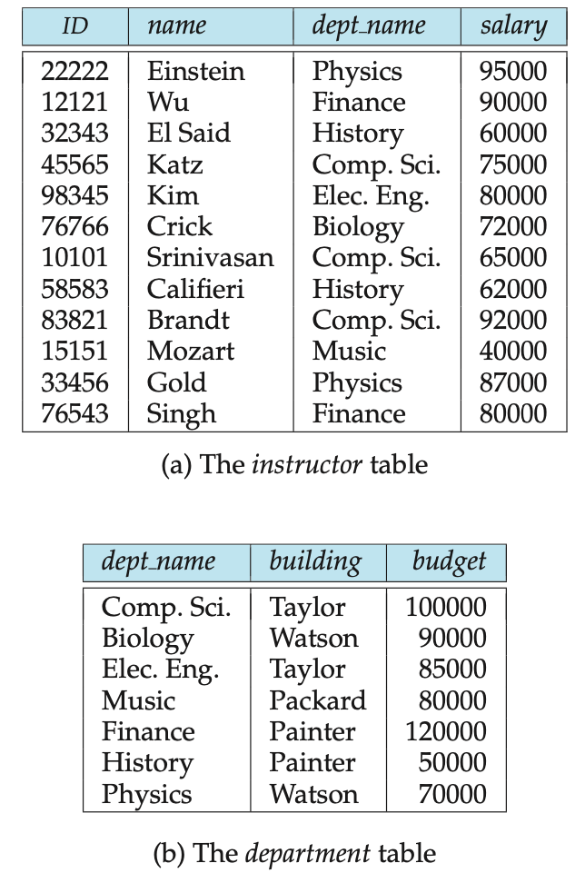

**Non-nested tables**

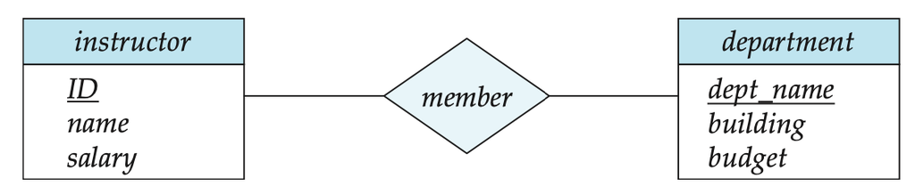

*Entity-Relationship model*

## 1.3 Brief History of Database and SQL

1. 1950s and early 1960s
- Data processing using magnetic tapes for storage
- Tapes provided only sequential access
- Punched cards for input
2. Late 1960s and 1970s
- Hard disks allowed direct access to data
- Network and hierarchical data models in widespread use
- Edgar (Ted) Frank Codd defines the relational data model

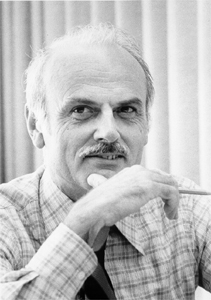

**Edgar (Ted) Frank Codd**

- IBM Research begins System R prototype
- UC Berkeley (Michael Stonebraker) begins Ingres prototype

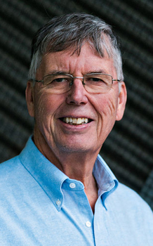

**Michael Stonebraker**

- Oracle releases first commercial relational database
- High-performance (for the era) transaction processing
3. 1980s
- Research relational prototypes evolve into commercial systems
- SQL becomes industrial standard
- Parallel and distributed database systems
- Object-oriented database systems
4. 1990s
- Large decision support and data-mining applications
- Large multi-terabyte data warehouses
- Emergence of Web commerce
5. 2000s
- Big data storage systems
- Google BigTable, Yahoo PNuts, Amazon,
- “NoSQL” systems.
- Big data analysis: beyond SQL
- Map reduce and friends
6. 2010s
- SQL reloaded
- SQL front end to Map Reduce systems
- Massively parallel database systems
- Multi-core main-memory databases

## 1.4 Database types

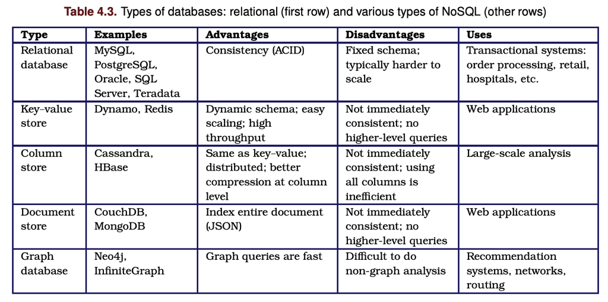

**SQL and NoSQL Databases**

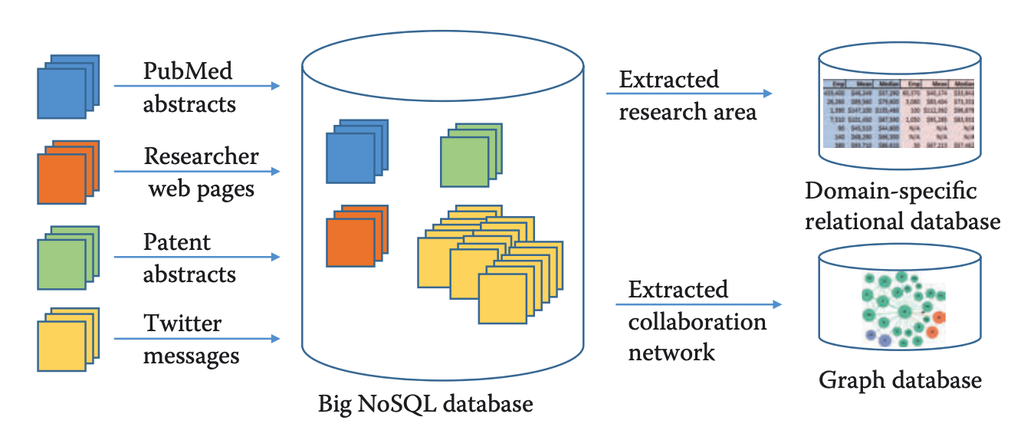

**NoSQL to Relational Database**

Source: Foster, Ian, Rayid Ghani, Ron S. Jarmin, Frauke Kreuter, and Julia Lane, eds. 2016. *Big data and social science: A practical guide to methods and tools*. crc Press.

# 2 Hands-on workshop I: SQL and database server

In this section, we demonstrate managing database using Structured Query Language (SQL).

- IBM researchers Donald D. Chamberlin and Raymond F. Boyce first developed a language named $SEQUEL$, later named Structured Query Language (SQL).
- IBM $SEQUEL$ language developed as part of System R project at the IBM San Jose Research Laboratory
- $SEQUEL$ later was renamed Structured Query Language (SQL)
- American National Standards Institute (ANSI) and International Organization for Standardization (ISO) standard SQL (most recent 2016 version)

## 2.1 SQL: DDL and DML

- The two major components of SQL are Data-definition language (DDL) and Data-manipulation language.
- Data-definition language (DDL) provides commands for defining relation schemas, deleting relations, and modifying relation schemas.
- Data-manipulation language (DML) provides the ability to query information from the database and to insert tuples into, delete tuples from, and modify tuples in the database.

### 2.1.1 DDL: Create table

- Database Schema

[figure not shown]

**Database Schema**

- Data types of attributes
  - character
    - $char(n)$: A fixed-length character string with user-specified length n.
    - $varchar(n)$: A variable-length character string with user-specified maximum length n.
    - The full form such as $character(n), varying character(n)$ can be used and is equivalent.
    - In general, $varchar(n)$ is preferred and recommended compared to $char(n)$ to avoid extra trailing spaces.
  - numeric
    - $int$: An integer
    - $smallint$: A small integer
    - $numeric(p, d)$: A fixed-point number with user-specified precision consisting of $p$ digits and $d$ of the $p$ digits to the right of the decimal point. Thus, $numeric(3, 1)$ allows $44. 5$ to be stored exactly, but neither $444. 5$ nor $0. 32$ can be stored exactly in a field of this type.
    - $real, double precision$: Floating-point and double-precision
    - $float(n)$: A floating-point number with precision of at least $n$ digits.
    - Example: Create a table

```sql
/** variable list:
pizza (4)
ice cream (2)
beer (2)
soda (4)
**/

CREATE TABLE fashions (id INTEGER PRIMARY KEY, name TEXT, quantity INTEGER );
```

- Integrity constraints
  - Types of integrity constraints:
  - primary key $(A_1, ..., A_n )$
  - foreign key $(A_m, ..., A_n )$ references $r$
  - not null
  - SQL prevents any update to the database that violates an integrity constraint.
  - Example:

```sql
create table instructor (
                 ID     char(5),
                 name       varchar(20) not null,
                 dept_name  varchar(20),
                 salary     numeric(8,2),
                 primary key (ID),
                 foreign key (dept_name) references department);
```

### 2.1.2 DML:

- Retrieval
- Insertion
- Deletion
- Modification
- SQL Commands:
1. Insert
   - insert into $instructor$ values (‘10211’, ‘Smith’, ‘Biology’, 66000);
2. Delete
   - Remove tuples from table
     - Example:
       - delete from $student$
3. Drop Table
   - drop table $r$
4. Select
- The select clause lists the attributes in a relation/table
- Example: find the names of all instructors:

```sql
select name
from instructor
```

- An asterisk in the select clause denotes “all attributes”

```sql
# Get all attributes/variables from instructor table
SELECT * from instructor
```

```sql
# Get some attributes/variables from instructor table
SELECT ID, salary from instructor
```

- The select clause can contain arithmetic expressions involving the operation, +, –,*, and /, and operating on constants or attributes of tuples.

```sql
select ID, name, salary/12
from instructor
```

5. From
- The from clause lists the relations involved in the query
- Corresponds to the Cartesian product operation of the relational algebra.
- Find the Cartesian product instructor $\times$ teaches

```sql
select *
from instructor, teaches
```

- What happens?
- It generates every possible instructor – teaches pair, with all attributes from both relations.
- Cartesian product not very useful directly, but useful combined with where-clause condition (selection operation in relational algebra).
6. Where
- The where clause specifies conditions that the result must satisfy
- To find all instructors in Comp. Sci. dept

```sql
select name
from instructor
where dept_name = 'Comp. Sci.'
```

- Comparisons can be applied to results of arithmetic expressions
- To find all instructors in Comp. Sci. dept with salary > 70000

```sql
select name
from instructor
where dept_name = 'Comp. Sci.'  and salary > 70000
```

## 2.2 In-class exercises

1. Open the Online SQL interpreter (https://www.db-book.com/db7/university-lab-dir/sqljs.html)
2. Write SQL codes to get a list of unique:
1. Students IDs (hint: from the *takes* relation/table)
2. Instructors (hint: from the *instructor* relation/table)
3. Departments (hint: from the *department* relation/table)
3. Write in SQL codes to do following queries:
1. Find the ID and name of each student who has taken at least one Comp. Sci. course; make sure there are no duplicate names in the result.
2. Add grades to the list
3. Find the ID and name of each student who has not taken any course offered before 2017. (hint: use the not in within the where clause)
4. For each department, find the maximum salary of instructors in that department. You may assume that every department has at least one instructor. (hint: use the max() function)
5. Find the lowest, across all departments, of the per-department maximum salary computed by the preceding query.
6. Add names to the list
4. Find instructor (with name and ID) who has never given an A grade in any course she or he has taught. (Instructors who have never taught a course trivially satisfy this condition.) (hint: use the except keyword)
5. Write SQL query to find the number of students in each section. The result columns should appear in the order “courseid, secid, year, semester, num”. You do not need to output sections with 0 students. (hint: use the count() function)

## 2.3 References:

- [Silberschatz, Abraham, Henry F. Korth, and Shashank Sudarshan. *Database system concepts*. New York: McGraw-Hill. 7th edition](https://www.db-book.com/db7/index.html)
- [SQL cheatsheet](https://cdn.sqltutorial.org/wp-content/uploads/2016/04/SQL-cheat-sheet.pdf)
- [PostgreSQL](https://www.postgresql.org/)
- [MySQL](https://www.mysql.com/downloads/)
- [Online SQL Interpreter](https://www.db-book.com/db7/university-lab-dir/sqljs.html)